# MetaModeling for sensetivity Analysis

Bisrat H. Gebrekidan

## Introduction

This notebook contatins all codes and results for the sensitivity analysis I did for the Bayesian belief network. The Objective here is to explore how each intensification strategy is affected by different configration of the parent nodes. In our BBN we have 7 states for our target node 'Intensification strategy', each states representing one intensification strategy or the combination of strategies. For the sensitivity Analysis we generated a parameters for the observed nodes using nearly orthogonal Latin Hypercube designs (Susan M. Sanchez, 2005). And for each combination of the observed nodes configration we calculated the probabilities of each state.

The main reference for the methods and code is [Python Machine Learning, 2nd Ed.](https://github.com/rasbt/python-machine-learning-book-2nd-edition)(Sebastian&Vahid,2017)

## Methods

Four different models were explored. The aim is given the configration of the parent nodes and the probabilities , which nodes or variables affect the probabilities of each intensification strategy. In order to answer the question we used four different models.

1. Regression tree
2. Random Forest regression
3. OLS regression
4. GLM regression with a logit link function

```python
import numpy as np
import pandas as pd
from sklearn.tree import DecisionTreeRegressor
import matplotlib.pyplot as plt
from sklearn import metrics
```

```python
#Read the data
DataFrame = pd.read_csv("FinalDoEForAnalysis.txt", sep="\t")
```

```python
#Look the data frame
DataFrame.head(5)
```

|  | ageOfTheHouseholdHead | householdSize | farmSize | shareOfHiredLabour | commercializationIndex | totalLabourManDays | farmType | creditaccess | cropChoice | perCapitaIncome | percentNonfarmIncome | topgraphicWetnessIndex | distanceToBigMarket | None | CropMultipleTimes | ApplyFertilizer | ApplyImprovedSeed | UseIrrigationAndFertilizerApplication | UseIrrigation | Other |
| --- | --- | --- | --- | --- | --- | --- | --- | --- | --- | --- | --- | --- | --- | --- | --- | --- | --- | --- | --- | --- |
| 0 | 50 | 10 | 10.30 | 61 | 62.89 | 899.96 | AgroPastoralist | No | RiceAndMaize | 626675 | 20.49 | 21.15 | 4.88 | 0.88340 | 0.01037 | 0.04267 | 0.01387 | 0.03742 | 0.00545 | 0.00683 |
| 1 | 32 | 5 | 14.36 | 96 | 71.88 | 538.28 | AgroPastoralist | No | VegitAndRice | 2337478 | 53.75 | 27.27 | 63.00 | 0.38313 | 0.04722 | 0.35824 | 0.14887 | 0.04543 | 0.00327 | 0.01384 |
| 2 | 34 | 7 | 2.43 | 56 | 96.09 | 815.31 | AgroPastoralist | No | RiceMaizeAndVegit | 1562078 | 17.47 | 18.73 | 8.99 | 0.25984 | 0.24503 | 0.12878 | 0.12207 | 0.17314 | 0.01390 | 0.05724 |
| 3 | 50 | 3 | 7.07 | 63 | 73.05 | 749.90 | AgroPastoralist | No | RiceAndMaize | 2140551 | 80.63 | 27.94 | 60.82 | 0.78165 | 0.03517 | 0.09984 | 0.01846 | 0.03151 | 0.01286 | 0.02051 |
| 4 | 48 | 7 | 10.62 | 41 | 92.97 | 796.07 | AgroPastoralist | No | Rice | 2989798 | 7.39 | 15.44 | 20.86 | 0.29317 | 0.08996 | 0.15584 | 0.27560 | 0.14692 | 0.01850 | 0.02001 |

```python
#Check the types and missing values of the data frame
DataFrame.info()
```

```
<class 'pandas.core.frame.DataFrame'>
RangeIndex: 257 entries, 0 to 256
Data columns (total 20 columns):
ageOfTheHouseholdHead                    257 non-null int64
householdSize                            257 non-null int64
farmSize                                 257 non-null float64
shareOfHiredLabour                       257 non-null int64
commercializationIndex                   257 non-null float64
totalLabourManDays                       257 non-null float64
farmType                                 257 non-null object
creditaccess                             257 non-null object
cropChoice                               257 non-null object
perCapitaIncome                          257 non-null int64
percentNonfarmIncome                     257 non-null float64
topgraphicWetnessIndex                   257 non-null float64
distanceToBigMarket                      257 non-null float64
None                                     257 non-null float64
CropMultipleTimes                        257 non-null float64
ApplyFertilizer                          257 non-null float64
ApplyImprovedSeed                        257 non-null float64
UseIrrigationAndFertilizerApplication    257 non-null float64
UseIrrigation                            257 non-null float64
Other                                    257 non-null float64
dtypes: float64(13), int64(4), object(3)
memory usage: 40.2+ KB
```

```python
#Encode our nominal variables as catagorical variables
DataFrame['farmType'] = DataFrame['farmType'].astype('category')
DataFrame['creditaccess'] = DataFrame['creditaccess'].astype('category')
DataFrame['cropChoice'] = DataFrame['cropChoice'].astype('category')
```

```python
#List of catagorical variables
CatagoricalVariables = ['farmType', 'cropChoice']
```

```python
#copy of the data frame
DataFrame2 = DataFrame
```

```python
DataFrame2.info()
```

```
<class 'pandas.core.frame.DataFrame'>
RangeIndex: 257 entries, 0 to 256
Data columns (total 20 columns):
ageOfTheHouseholdHead                    257 non-null int64
householdSize                            257 non-null int64
farmSize                                 257 non-null float64
shareOfHiredLabour                       257 non-null int64
commercializationIndex                   257 non-null float64
totalLabourManDays                       257 non-null float64
farmType                                 257 non-null category
creditaccess                             257 non-null category
cropChoice                               257 non-null category
perCapitaIncome                          257 non-null int64
percentNonfarmIncome                     257 non-null float64
topgraphicWetnessIndex                   257 non-null float64
distanceToBigMarket                      257 non-null float64
None                                     257 non-null float64
CropMultipleTimes                        257 non-null float64
ApplyFertilizer                          257 non-null float64
ApplyImprovedSeed                        257 non-null float64
UseIrrigationAndFertilizerApplication    257 non-null float64
UseIrrigation                            257 non-null float64
Other                                    257 non-null float64
dtypes: category(3), float64(13), int64(4)
memory usage: 35.0 KB
```

```python
DataFrame.head(5)
```

|  | ageOfTheHouseholdHead | householdSize | farmSize | shareOfHiredLabour | commercializationIndex | totalLabourManDays | farmType | creditaccess | cropChoice | perCapitaIncome | percentNonfarmIncome | topgraphicWetnessIndex | distanceToBigMarket | None | CropMultipleTimes | ApplyFertilizer | ApplyImprovedSeed | UseIrrigationAndFertilizerApplication | UseIrrigation | Other |
| --- | --- | --- | --- | --- | --- | --- | --- | --- | --- | --- | --- | --- | --- | --- | --- | --- | --- | --- | --- | --- |
| 0 | 50 | 10 | 10.30 | 61 | 62.89 | 899.96 | AgroPastoralist | No | RiceAndMaize | 626675 | 20.49 | 21.15 | 4.88 | 0.88340 | 0.01037 | 0.04267 | 0.01387 | 0.03742 | 0.00545 | 0.00683 |
| 1 | 32 | 5 | 14.36 | 96 | 71.88 | 538.28 | AgroPastoralist | No | VegitAndRice | 2337478 | 53.75 | 27.27 | 63.00 | 0.38313 | 0.04722 | 0.35824 | 0.14887 | 0.04543 | 0.00327 | 0.01384 |
| 2 | 34 | 7 | 2.43 | 56 | 96.09 | 815.31 | AgroPastoralist | No | RiceMaizeAndVegit | 1562078 | 17.47 | 18.73 | 8.99 | 0.25984 | 0.24503 | 0.12878 | 0.12207 | 0.17314 | 0.01390 | 0.05724 |
| 3 | 50 | 3 | 7.07 | 63 | 73.05 | 749.90 | AgroPastoralist | No | RiceAndMaize | 2140551 | 80.63 | 27.94 | 60.82 | 0.78165 | 0.03517 | 0.09984 | 0.01846 | 0.03151 | 0.01286 | 0.02051 |
| 4 | 48 | 7 | 10.62 | 41 | 92.97 | 796.07 | AgroPastoralist | No | Rice | 2989798 | 7.39 | 15.44 | 20.86 | 0.29317 | 0.08996 | 0.15584 | 0.27560 | 0.14692 | 0.01850 | 0.02001 |

```python
#Encde the catagorical variables using one hot encoding(requirement for most of the algorithms in sklearn)
for features in CatagoricalVariables:
    one_hot = pd.get_dummies(DataFrame2[features], prefix=features)
    DataFrame2 = DataFrame2.drop(features, axis=1)
    DataFrame2 = DataFrame2.join(one_hot)
```

```python
from sklearn.preprocessing import LabelEncoder

enc = LabelEncoder()
label_encoder = enc.fit(DataFrame2['creditaccess'])
integer_class= label_encoder.transform(label_encoder.classes_)
t = label_encoder.transform(DataFrame2['creditaccess'])
DataFrame2['creditaccess'] = t
```

```python
dependentVariables = ['ageOfTheHouseholdHead', 'householdSize', 'farmSize',
       'shareOfHiredLabour', 'commercializationIndex', 'totalLabourManDays',
       'perCapitaIncome',
       'percentNonfarmIncome', 'topgraphicWetnessIndex',
       'distanceToBigMarket', 'farmType_ AgroPastoralist', 'farmType_ Diversifier',
       'farmType_ Subsistence', 'cropChoice_ Maize', 'cropChoice_ Rice', 'cropChoice_ RiceAndMaize',
       'cropChoice_ RiceMaizeAndVegit', 'cropChoice_ VegitAndRice']
outComeVariables =['None', 'CropMultipleTimes',
       'ApplyFertilizer', 'ApplyImprovedSeed',
       'UseIrrigationAndFertilizerApplication', 'UseIrrigation']
```

```python
DataFrame2.head(10)
```

|  | ageOfTheHouseholdHead | householdSize | farmSize | shareOfHiredLabour | commercializationIndex | totalLabourManDays | creditaccess | perCapitaIncome | percentNonfarmIncome | topgraphicWetnessIndex | ... | UseIrrigation | Other | farmType_ AgroPastoralist | farmType_ Diversifier | farmType_ Subsistence | cropChoice_ Maize | cropChoice_ Rice | cropChoice_ RiceAndMaize | cropChoice_ RiceMaizeAndVegit | cropChoice_ VegitAndRice |
| --- | --- | --- | --- | --- | --- | --- | --- | --- | --- | --- | --- | --- | --- | --- | --- | --- | --- | --- | --- | --- | --- |
| 0 | 50 | 10 | 10.30 | 61 | 62.89 | 899.96 | 0 | 626675 | 20.49 | 21.15 | ... | 0.00545 | 0.00683 | 1.0 | 0.0 | 0.0 | 0.0 | 0.0 | 1.0 | 0.0 | 0.0 |
| 1 | 32 | 5 | 14.36 | 96 | 71.88 | 538.28 | 0 | 2337478 | 53.75 | 27.27 | ... | 0.00327 | 0.01384 | 1.0 | 0.0 | 0.0 | 0.0 | 0.0 | 0.0 | 0.0 | 1.0 |
| 2 | 34 | 7 | 2.43 | 56 | 96.09 | 815.31 | 0 | 1562078 | 17.47 | 18.73 | ... | 0.01390 | 0.05724 | 1.0 | 0.0 | 0.0 | 0.0 | 0.0 | 0.0 | 1.0 | 0.0 |
| 3 | 50 | 3 | 7.07 | 63 | 73.05 | 749.90 | 0 | 2140551 | 80.63 | 27.94 | ... | 0.01286 | 0.02051 | 1.0 | 0.0 | 0.0 | 0.0 | 0.0 | 1.0 | 0.0 | 0.0 |
| 4 | 48 | 7 | 10.62 | 41 | 92.97 | 796.07 | 0 | 2989798 | 7.39 | 15.44 | ... | 0.01850 | 0.02001 | 1.0 | 0.0 | 0.0 | 0.0 | 1.0 | 0.0 | 0.0 | 0.0 |
| 5 | 52 | 5 | 16.29 | 16 | 86.33 | 907.66 | 0 | 1857468 | 72.23 | 27.60 | ... | 0.02945 | 0.02517 | 0.0 | 1.0 | 0.0 | 0.0 | 0.0 | 0.0 | 1.0 | 0.0 |
| 6 | 27 | 7 | 7.78 | 12 | 51.56 | 526.74 | 0 | 2263630 | 0.34 | 19.14 | ... | 0.01109 | 0.04058 | 1.0 | 0.0 | 0.0 | 0.0 | 0.0 | 0.0 | 1.0 | 0.0 |
| 7 | 49 | 1 | 6.56 | 40 | 92.58 | 746.05 | 0 | 638983 | 39.98 | 23.64 | ... | 0.02795 | 0.05015 | 0.0 | 1.0 | 0.0 | 0.0 | 0.0 | 0.0 | 0.0 | 1.0 |
| 8 | 29 | 6 | 15.84 | 63 | 38.67 | 788.38 | 0 | 1623617 | 81.30 | 18.46 | ... | 0.00301 | 0.02122 | 0.0 | 1.0 | 0.0 | 0.0 | 0.0 | 1.0 | 0.0 | 0.0 |
| 9 | 55 | 2 | 14.74 | 72 | 4.30 | 615.23 | 0 | 2780563 | 34.60 | 26.26 | ... | 0.03187 | 0.03487 | 0.0 | 1.0 | 0.0 | 1.0 | 0.0 | 0.0 | 0.0 | 0.0 |

10 rows × 26 columns

```python
DataFrame2.info()
```

```
<class 'pandas.core.frame.DataFrame'>
RangeIndex: 257 entries, 0 to 256
Data columns (total 26 columns):
ageOfTheHouseholdHead                    257 non-null int64
householdSize                            257 non-null int64
farmSize                                 257 non-null float64
shareOfHiredLabour                       257 non-null int64
commercializationIndex                   257 non-null float64
totalLabourManDays                       257 non-null float64
creditaccess                             257 non-null int64
perCapitaIncome                          257 non-null int64
percentNonfarmIncome                     257 non-null float64
topgraphicWetnessIndex                   257 non-null float64
distanceToBigMarket                      257 non-null float64
None                                     257 non-null float64
CropMultipleTimes                        257 non-null float64
ApplyFertilizer                          257 non-null float64
ApplyImprovedSeed                        257 non-null float64
UseIrrigationAndFertilizerApplication    257 non-null float64
UseIrrigation                            257 non-null float64
Other                                    257 non-null float64
farmType_ AgroPastoralist                257 non-null float64
farmType_ Diversifier                    257 non-null float64
farmType_ Subsistence                    257 non-null float64
cropChoice_ Maize                        257 non-null float64
cropChoice_ Rice                         257 non-null float64
cropChoice_ RiceAndMaize                 257 non-null float64
cropChoice_ RiceMaizeAndVegit            257 non-null float64
cropChoice_ VegitAndRice                 257 non-null float64
dtypes: float64(21), int64(5)
memory usage: 52.3 KB
```

# Regression Tree

Since the target variable does not have classes, we fit a regression model to the target variable using each of the independent variables. Then for each independent variable, the data is split at several split points. At each split point, the "error" between the predicted value and the actual values is squared to get a "Sum of Squared Errors (SSE)". The split point errors across the variables are compared and the variable/point yielding the lowest SSE is chosen as the root node/split point. This process is recursively continued.

```python
#A generic function to perform regression tree for all the outcome variables and also display feature importance
from sklearn import tree
import pydotplus
from IPython.display import IFrame
def doRegressionTree(Data, dependentVars, OutComeVar):
    model = DecisionTreeRegressor(max_depth=5, min_samples_split=10, max_features=4, min_samples_leaf=20)
    for outCome in OutComeVar:
        print('***************************')
        print('***************************')
        print(outCome)
        print('***************************')
        model.fit(Data[dependentVars], Data[outCome])

        score = model.score(Data[dependentVars], Data[outCome])
        #print(score)

        print "Score is : %s" % "{0:.3%}".format(score)


        X = Data[dependentVars]
        importances = model.feature_importances_
        featureImportance = pd.Series(model.feature_importances_, index=dependentVars).sort_values(ascending=False)
        print featureImportance

        featureImportance.plot.bar(color ='r')
        plt.title("Feature Importance " + outCome)
        plt.show()



        # plot the decision tree

        dot_data = tree.export_graphviz(model, out_file=None, feature_names=dependentVars)
        graph = pydotplus.graph_from_dot_data(dot_data)
        graph.write_pdf(outCome+".pdf")
        IFrame((outCome +".pdf"), width=600, height=600)
```

```
None
Score is : 16.628%
commercializationIndex           0.476285
householdSize                    0.184423
ageOfTheHouseholdHead            0.162448
perCapitaIncome                  0.099415
topgraphicWetnessIndex           0.057602
shareOfHiredLabour               0.019827
farmType_ Subsistence            0.000000
farmType_ Diversifier            0.000000
farmType_ AgroPastoralist        0.000000
distanceToBigMarket              0.000000
cropChoice_ RiceMaizeAndVegit    0.000000
percentNonfarmIncome             0.000000
cropChoice_ Maize                0.000000
totalLabourManDays               0.000000
cropChoice_ Rice                 0.000000
farmSize                         0.000000
cropChoice_ RiceAndMaize         0.000000
cropChoice_ VegitAndRice         0.000000
dtype: float64
```

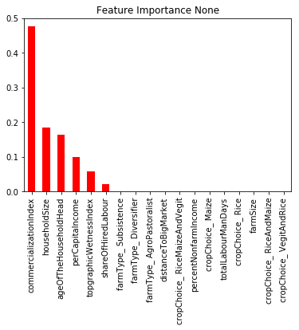

```
CropMultipleTimes
Score is : 27.413%
totalLabourManDays               0.255052
commercializationIndex           0.254097
topgraphicWetnessIndex           0.212601
perCapitaIncome                  0.100249
distanceToBigMarket              0.096519
householdSize                    0.079749
farmSize                         0.001732
percentNonfarmIncome             0.000000
shareOfHiredLabour               0.000000
cropChoice_ VegitAndRice         0.000000
cropChoice_ RiceMaizeAndVegit    0.000000
farmType_ AgroPastoralist        0.000000
farmType_ Diversifier            0.000000
farmType_ Subsistence            0.000000
cropChoice_ Maize                0.000000
cropChoice_ Rice                 0.000000
cropChoice_ RiceAndMaize         0.000000
ageOfTheHouseholdHead            0.000000
dtype: float64
```

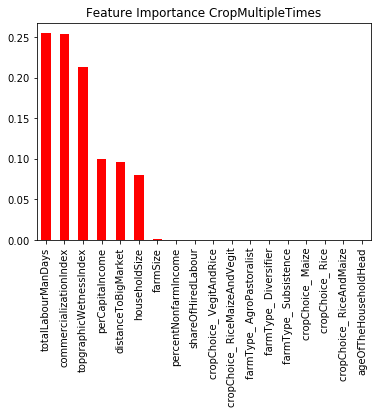

```
ApplyFertilizer
Score is : 24.900%
topgraphicWetnessIndex           0.485845
farmType_ Diversifier            0.148720
ageOfTheHouseholdHead            0.138407
farmSize                         0.110972
commercializationIndex           0.058138
distanceToBigMarket              0.044459
percentNonfarmIncome             0.013460
cropChoice_ Rice                 0.000000
cropChoice_ Maize                0.000000
farmType_ Subsistence            0.000000
cropChoice_ RiceAndMaize         0.000000
farmType_ AgroPastoralist        0.000000
cropChoice_ RiceMaizeAndVegit    0.000000
perCapitaIncome                  0.000000
totalLabourManDays               0.000000
shareOfHiredLabour               0.000000
householdSize                    0.000000
cropChoice_ VegitAndRice         0.000000
dtype: float64
```

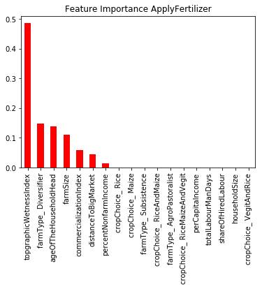

```
ApplyImprovedSeed
Score is : 26.662%
percentNonfarmIncome             0.329139
ageOfTheHouseholdHead            0.151728
householdSize                    0.144958
distanceToBigMarket              0.136065
farmSize                         0.110505
commercializationIndex           0.077695
farmType_ Diversifier            0.049909
shareOfHiredLabour               0.000000
totalLabourManDays               0.000000
perCapitaIncome                  0.000000
cropChoice_ VegitAndRice         0.000000
cropChoice_ RiceMaizeAndVegit    0.000000
farmType_ AgroPastoralist        0.000000
farmType_ Subsistence            0.000000
cropChoice_ Maize                0.000000
cropChoice_ Rice                 0.000000
cropChoice_ RiceAndMaize         0.000000
topgraphicWetnessIndex           0.000000
dtype: float64
```

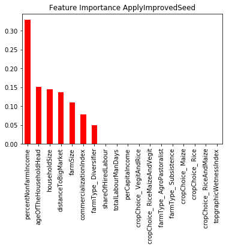

```
UseIrrigationAndFertilizerApplication
Score is : 33.703%
distanceToBigMarket              0.594549
farmSize                         0.213213
percentNonfarmIncome             0.116522
topgraphicWetnessIndex           0.038844
commercializationIndex           0.025117
farmType_ Diversifier            0.010890
farmType_ Subsistence            0.000864
perCapitaIncome                  0.000000
householdSize                    0.000000
shareOfHiredLabour               0.000000
totalLabourManDays               0.000000
cropChoice_ VegitAndRice         0.000000
cropChoice_ RiceMaizeAndVegit    0.000000
farmType_ AgroPastoralist        0.000000
cropChoice_ Maize                0.000000
cropChoice_ Rice                 0.000000
cropChoice_ RiceAndMaize         0.000000
ageOfTheHouseholdHead            0.000000
dtype: float64
```

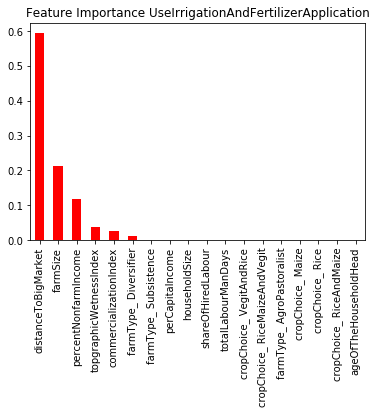

```
UseIrrigation
Score is : 16.853%
topgraphicWetnessIndex           0.346848
percentNonfarmIncome             0.250300
farmSize                         0.188927
farmType_ Subsistence            0.125031
totalLabourManDays               0.087095
householdSize                    0.001798
shareOfHiredLabour               0.000000
commercializationIndex           0.000000
perCapitaIncome                  0.000000
cropChoice_ VegitAndRice         0.000000
cropChoice_ RiceMaizeAndVegit    0.000000
distanceToBigMarket              0.000000
farmType_ AgroPastoralist        0.000000
farmType_ Diversifier            0.000000
cropChoice_ Maize                0.000000
cropChoice_ Rice                 0.000000
cropChoice_ RiceAndMaize         0.000000
ageOfTheHouseholdHead            0.000000
dtype: float64
```

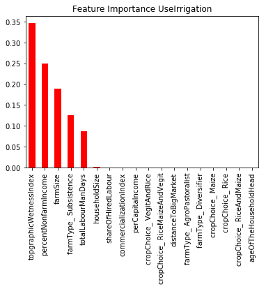

```python
doRegressionTree(DataFrame2, dependentVariables, outComeVariables)
```

```python
#Display the regression trees generated
    from wand.image import Image as WImage
    from IPython.display import display
    for name in outComeVariables:
        print('==================================================')
        print('RegressionTree for ' + name)
        print('==================================================')
        img = WImage(filename=name+'.pdf', height=900, width=900)
        display(img)
```

```
    ==================================================
    RegressionTree for None
    ==================================================
```

[figure not shown]

```
    ==================================================
    RegressionTree for CropMultipleTimes
    ==================================================
```

[figure not shown]

```
    ==================================================
    RegressionTree for ApplyFertilizer
    ==================================================
```

[figure not shown]

```
    ==================================================
    RegressionTree for ApplyImprovedSeed
    ==================================================
```

[figure not shown]

```
    ==================================================
    RegressionTree for UseIrrigationAndFertilizerApplication
    ==================================================
```

[figure not shown]

```
    ==================================================
    RegressionTree for UseIrrigation
    ==================================================
```

[figure not shown]

# Random Forest

The general random forest algorithm can be decribed in the following four steps steps (ref: Python Machine Learning by Sebastian Raschka):

1. Draw a random bootstrap sample of size n (randomly choose n samples from the training set with replacement).
2. Grow a decision tree from the bootstrap sample. At each node:
   - Randomly select features without replacement.
   - Split the node using the feature that provides the best split according to the objective function, for instance, by maximizing the information gain.
3. Repeat the steps 1 to 2k times.
4. Aggregate the prediction by each tree to assign the class label by majority vote.

Random forests don't provide the same level of interpretability as regressoin trees[no regression tree for display]. However, a big advantage of random forests is that as the ensemble model is quite robust and resistant to noise from the individual regression trees, we typically don't need to prune the random forest

```python
#A function to do a randome forest regression for each of the intentesification strategy
#and calculate the accuracy of the model
#and also provide feature importance
from sklearn.ensemble import RandomForestRegressor

def doRandomForestRegression(Data, dependentVars, OutComeVar):
    model = RandomForestRegressor(n_estimators=25, min_samples_split=25, max_depth=7, min_samples_leaf=15)
    for outCome in OutComeVar:
        print('***************************')
        print('***************************')
        print(outCome)
        print('***************************')
        model.fit(Data[dependentVars], Data[outCome])

        score = model.score(Data[dependentVars], Data[outCome])
        #print(score)

        print "Score is : %s" % "{0:.3%}".format(score)

        X = Data[dependentVars]
        importances = model.feature_importances_
        featureImportance = pd.Series(importances, index=dependentVars).sort_values(ascending=False)
        print featureImportance

        featureImportance.plot.bar(color ='g')
        plt.title("Feature Importance " + outCome)
        plt.show()
```

```
None
Score is : 43.398%
farmSize                         0.167360
totalLabourManDays               0.166757
percentNonfarmIncome             0.143645
farmType_ AgroPastoralist        0.103926
commercializationIndex           0.101550
farmType_ Subsistence            0.063931
ageOfTheHouseholdHead            0.057521
topgraphicWetnessIndex           0.051501
shareOfHiredLabour               0.032672
distanceToBigMarket              0.029035
cropChoice_ RiceAndMaize         0.027198
farmType_ Diversifier            0.018283
householdSize                    0.018084
perCapitaIncome                  0.013670
cropChoice_ Rice                 0.004866
cropChoice_ RiceMaizeAndVegit    0.000000
cropChoice_ Maize                0.000000
cropChoice_ VegitAndRice         0.000000
dtype: float64
```

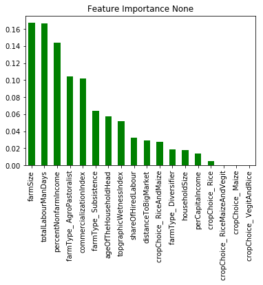

```
CropMultipleTimes
Score is : 39.911%
percentNonfarmIncome             0.275230
totalLabourManDays               0.154278
distanceToBigMarket              0.114974
commercializationIndex           0.095281
topgraphicWetnessIndex           0.074241
farmSize                         0.070193
perCapitaIncome                  0.058113
ageOfTheHouseholdHead            0.056249
householdSize                    0.042415
shareOfHiredLabour               0.025539
farmType_ Diversifier            0.016508
farmType_ Subsistence            0.014910
cropChoice_ RiceMaizeAndVegit    0.002070
farmType_ AgroPastoralist        0.000000
cropChoice_ Maize                0.000000
cropChoice_ Rice                 0.000000
cropChoice_ RiceAndMaize         0.000000
cropChoice_ VegitAndRice         0.000000
dtype: float64
```

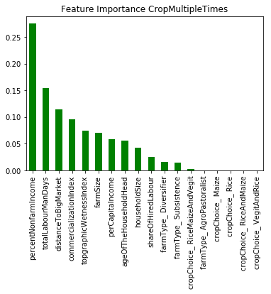

```
ApplyFertilizer
Score is : 33.636%
topgraphicWetnessIndex           0.390882
commercializationIndex           0.175383
percentNonfarmIncome             0.164959
ageOfTheHouseholdHead            0.092468
totalLabourManDays               0.067492
shareOfHiredLabour               0.025734
householdSize                    0.024458
perCapitaIncome                  0.018695
farmSize                         0.015839
distanceToBigMarket              0.014125
farmType_ Diversifier            0.008299
farmType_ Subsistence            0.001667
cropChoice_ Maize                0.000000
farmType_ AgroPastoralist        0.000000
cropChoice_ RiceMaizeAndVegit    0.000000
cropChoice_ Rice                 0.000000
cropChoice_ RiceAndMaize         0.000000
cropChoice_ VegitAndRice         0.000000
dtype: float64
```

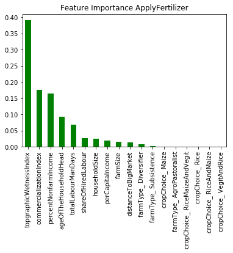

```
ApplyImprovedSeed
Score is : 39.859%
percentNonfarmIncome             0.479935
distanceToBigMarket              0.140579
commercializationIndex           0.089470
topgraphicWetnessIndex           0.050815
householdSize                    0.045030
ageOfTheHouseholdHead            0.044001
farmType_ Subsistence            0.040763
farmSize                         0.033188
perCapitaIncome                  0.020015
totalLabourManDays               0.018643
shareOfHiredLabour               0.012930
farmType_ Diversifier            0.010323
cropChoice_ RiceMaizeAndVegit    0.010316
cropChoice_ RiceAndMaize         0.002973
cropChoice_ VegitAndRice         0.001018
farmType_ AgroPastoralist        0.000000
cropChoice_ Maize                0.000000
cropChoice_ Rice                 0.000000
dtype: float64
```

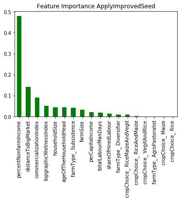

```
UseIrrigationAndFertilizerApplication
Score is : 45.349%
distanceToBigMarket              0.597441
topgraphicWetnessIndex           0.113155
householdSize                    0.099426
percentNonfarmIncome             0.077960
commercializationIndex           0.062228
farmSize                         0.018917
ageOfTheHouseholdHead            0.015645
totalLabourManDays               0.013799
perCapitaIncome                  0.000864
shareOfHiredLabour               0.000565
farmType_ AgroPastoralist        0.000000
farmType_ Diversifier            0.000000
cropChoice_ RiceMaizeAndVegit    0.000000
farmType_ Subsistence            0.000000
cropChoice_ Maize                0.000000
cropChoice_ Rice                 0.000000
cropChoice_ RiceAndMaize         0.000000
cropChoice_ VegitAndRice         0.000000
dtype: float64
```

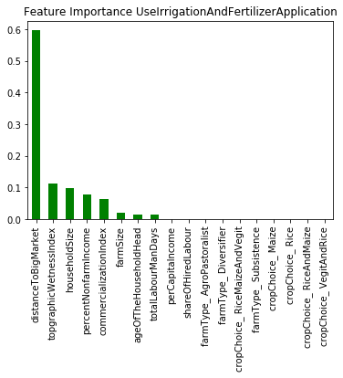

```
UseIrrigation
Score is : 48.446%
distanceToBigMarket              0.693749
topgraphicWetnessIndex           0.103092
farmSize                         0.089504
percentNonfarmIncome             0.062654
ageOfTheHouseholdHead            0.026815
farmType_ Diversifier            0.009940
totalLabourManDays               0.005313
commercializationIndex           0.003833
shareOfHiredLabour               0.002644
householdSize                    0.001338
perCapitaIncome                  0.001116
farmType_ Subsistence            0.000000
farmType_ AgroPastoralist        0.000000
cropChoice_ Maize                0.000000
cropChoice_ RiceMaizeAndVegit    0.000000
cropChoice_ Rice                 0.000000
cropChoice_ RiceAndMaize         0.000000
cropChoice_ VegitAndRice         0.000000
dtype: float64
```

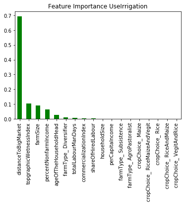

```python
#call the randome forest function
doRandomForestRegression(DataFrame2, dependentVariables, outComeVariables)
```

# OLS Regression

```python
# A function to estimate a OLS Regression

import statsmodels.api as sm
def doOLSRegression(Data, dependentVars, OutComeVar):
    for outCome in OutComeVar:
        model = sm.OLS(Data[outCome], Data[dependentVars])
        res = model.fit()
        print('************************************')
        print('OLS Regression for ' + outCome)
        print('************************************')
        print(res.summary())
```

```python
#call the OLS function
doOLSRegression(DataFrame2, dependentVariables, outComeVariables)
```

```
OLS Regression for None
                            OLS Regression Results
==============================================================================
Dep. Variable:                   None   R-squared:                       0.272
Model:                            OLS   Adj. R-squared:                  0.223
Method:                 Least Squares   F-statistic:                     5.599
Date:                Thu, 20 Jul 2017   Prob (F-statistic):           3.40e-10
Time:                        22:38:51   Log-Likelihood:                 40.470
No. Observations:                 257   AIC:                            -46.94
Df Residuals:                     240   BIC:                             13.39
Df Model:                          16
Covariance Type:            nonrobust
=================================================================================================
                                    coef    std err          t      P>|t|      [95.0% Conf. Int.]
-------------------------------------------------------------------------------------------------
ageOfTheHouseholdHead            -0.0008      0.001     -1.068      0.287        -0.002     0.001
householdSize                     0.0115      0.005      2.526      0.012         0.003     0.021
farmSize                         -0.0071      0.003     -2.523      0.012        -0.013    -0.002
shareOfHiredLabour               -0.0001      0.000     -0.305      0.761        -0.001     0.001
commercializationIndex           -0.0012      0.000     -2.534      0.012        -0.002    -0.000
totalLabourManDays               -0.0002   4.76e-05     -3.871      0.000        -0.000 -9.05e-05
perCapitaIncome                 4.53e-09   1.46e-08      0.309      0.757     -2.43e-08  3.34e-08
percentNonfarmIncome              0.0015      0.001      2.807      0.005         0.000     0.003
topgraphicWetnessIndex           -0.0053      0.003     -1.978      0.049        -0.011 -2.23e-05
distanceToBigMarket           -1.036e-05      0.001     -0.014      0.989        -0.001     0.001
farmType_ AgroPastoralist         0.4668      0.068      6.840      0.000         0.332     0.601
farmType_ Diversifier             0.3617      0.066      5.460      0.000         0.231     0.492
farmType_ Subsistence             0.2460      0.068      3.627      0.000         0.112     0.380
cropChoice_ Maize                 0.2086      0.051      4.091      0.000         0.108     0.309
cropChoice_ Rice                  0.1417      0.052      2.736      0.007         0.040     0.244
cropChoice_ RiceAndMaize          0.2941      0.046      6.329      0.000         0.203     0.386
cropChoice_ RiceMaizeAndVegit     0.2217      0.045      4.936      0.000         0.133     0.310
cropChoice_ VegitAndRice          0.2084      0.046      4.577      0.000         0.119     0.298
==============================================================================
Omnibus:                       14.234   Durbin-Watson:                   1.875
Prob(Omnibus):                  0.001   Jarque-Bera (JB):               15.167
Skew:                           0.589   Prob(JB):                     0.000509
Kurtosis:                       3.169   Cond. No.                     2.41e+22
==============================================================================

```

[output cut: 209 more lines]

```
cropChoice_ Rice                 -0.0016      0.009     -0.186      0.853        -0.018     0.015
cropChoice_ RiceAndMaize         -0.0122      0.008     -1.603      0.110        -0.027     0.003
cropChoice_ RiceMaizeAndVegit    -0.0063      0.007     -0.847      0.398        -0.021     0.008
cropChoice_ VegitAndRice          0.0004      0.007      0.052      0.959        -0.014     0.015
==============================================================================
Omnibus:                      176.695   Durbin-Watson:                   1.986
Prob(Omnibus):                  0.000   Jarque-Bera (JB):             1524.179
Skew:                           2.763   Prob(JB):                         0.00
Kurtosis:                      13.574   Cond. No.                     2.41e+22
==============================================================================

Warnings:
[1] Standard Errors assume that the covariance matrix of the errors is correctly specified.
[2] The smallest eigenvalue is 2.13e-30. This might indicate that there are
strong multicollinearity problems or that the design matrix is singular.
```

# GLM Regression

```python
#when the dependent variable is a proportion or fraction OLS estimated are biased
#and provide predicated value less than 0 or greater than 1
#A better alternative is to estimate using glm with family(binomial), link(logit),
#and robust; this is the method proposed by Papke and Wooldridge (1996)
#http://www.stata.com/support/faqs/statistics/logit-transformation/
from statsmodels.graphics.api import abline_plot
def doGLMRegression(Data, dependentVars, OutComeVar):
    for outCome in OutComeVar:
        model = sm.GLM(Data[outCome], Data[dependentVars], family=sm.families.Binomial())
        res = model.fit()
        print('************************************')
        print('GLM Regression for ' + outCome)
        print('************************************')
        print(res.summary())
        yhat = res.mu
        y =Data[outCome]
        fig, ax = plt.subplots()
        ax.scatter(yhat, y)
        line_fit = sm.OLS(y, sm.add_constant(yhat, prepend=True)).fit()
        abline_plot(model_results=line_fit, ax=ax)

        #plot the regression line between the actual probability values and
        # the predicted probability values

        ax.set_title('Model Fit Plot ' + outCome)
        ax.set_ylabel('Observed values')
        ax.set_xlabel('Fitted values');
        plt.show()
```

```
GLM Regression for None
                 Generalized Linear Model Regression Results
==============================================================================
Dep. Variable:                   None   No. Observations:                  257
Model:                            GLM   Df Residuals:                      240
Model Family:                Binomial   Df Model:                           16
Link Function:                  logit   Scale:                             1.0
Method:                          IRLS   Log-Likelihood:                -155.30
Date:                Thu, 20 Jul 2017   Deviance:                       224.07
Time:                        22:39:39   Pearson chi2:                     54.4
No. Iterations:                     7
=================================================================================================
                                    coef    std err          z      P>|z|      [95.0% Conf. Int.]
-------------------------------------------------------------------------------------------------
ageOfTheHouseholdHead            -0.0035      0.007     -0.470      0.639        -0.018     0.011
householdSize                     0.0554      0.047      1.181      0.238        -0.037     0.147
farmSize                         -0.0332      0.029     -1.154      0.249        -0.090     0.023
shareOfHiredLabour               -0.0007      0.005     -0.146      0.884        -0.010     0.009
commercializationIndex           -0.0056      0.005     -1.178      0.239        -0.015     0.004
totalLabourManDays               -0.0009      0.000     -1.784      0.074        -0.002  8.64e-05
perCapitaIncome                2.178e-08    1.5e-07      0.145      0.884     -2.72e-07  3.15e-07
percentNonfarmIncome              0.0072      0.006      1.298      0.194        -0.004     0.018
topgraphicWetnessIndex           -0.0253      0.028     -0.912      0.362        -0.080     0.029
distanceToBigMarket            1.753e-05      0.008      0.002      0.998        -0.015     0.015
farmType_ AgroPastoralist         0.7320      0.697      1.051      0.293        -0.633     2.097
farmType_ Diversifier             0.2726      0.676      0.403      0.687        -1.053     1.598
farmType_ Subsistence            -0.3190      0.703     -0.454      0.650        -1.697     1.059
cropChoice_ Maize                 0.1151      0.524      0.220      0.826        -0.912     1.143
cropChoice_ Rice                 -0.2218      0.539     -0.412      0.681        -1.278     0.834
cropChoice_ RiceAndMaize          0.5109      0.475      1.075      0.282        -0.421     1.442
cropChoice_ RiceMaizeAndVegit     0.1711      0.460      0.372      0.710        -0.730     1.072
cropChoice_ VegitAndRice          0.1102      0.469      0.235      0.814        -0.809     1.030
=================================================================================================
```

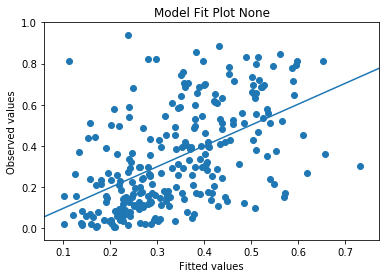

```
GLM Regression for CropMultipleTimes
                 Generalized Linear Model Regression Results
==============================================================================
Dep. Variable:      CropMultipleTimes   No. Observations:                  257
Model:                            GLM   Df Residuals:                      240
Model Family:                Binomial   Df Model:                           16
Link Function:                  logit   Scale:                             1.0
Method:                          IRLS   Log-Likelihood:                -124.71
Date:                Thu, 20 Jul 2017   Deviance:                       119.85
Time:                        22:39:39   Pearson chi2:                     31.6
No. Iterations:                     8
=================================================================================================
                                    coef    std err          z      P>|z|      [95.0% Conf. Int.]
-------------------------------------------------------------------------------------------------
ageOfTheHouseholdHead             0.0046      0.009      0.537      0.591        -0.012     0.021
householdSize                    -0.0570      0.054     -1.048      0.295        -0.164     0.050
farmSize                         -0.0283      0.033     -0.847      0.397        -0.094     0.037
shareOfHiredLabour               -0.0026      0.005     -0.478      0.633        -0.013     0.008
commercializationIndex           -0.0038      0.005     -0.690      0.490        -0.015     0.007
totalLabourManDays                0.0007      0.001      1.209      0.227        -0.000     0.002
perCapitaIncome                -1.12e-07   1.74e-07     -0.644      0.520     -4.53e-07  2.29e-07
percentNonfarmIncome             -0.0109      0.006     -1.688      0.091        -0.024     0.002
topgraphicWetnessIndex            0.0213      0.032      0.667      0.505        -0.041     0.084
distanceToBigMarket               0.0071      0.009      0.805      0.421        -0.010     0.024
farmType_ AgroPastoralist        -0.9659      0.816     -1.183      0.237        -2.566     0.634
farmType_ Diversifier            -0.7256      0.782     -0.928      0.353        -2.258     0.807
farmType_ Subsistence            -0.4855      0.799     -0.608      0.544        -2.052     1.081
cropChoice_ Maize                -0.5151      0.608     -0.848      0.397        -1.706     0.676
cropChoice_ Rice                 -0.3350      0.602     -0.557      0.578        -1.514     0.844
cropChoice_ RiceAndMaize         -0.4034      0.553     -0.730      0.465        -1.487     0.680
cropChoice_ RiceMaizeAndVegit    -0.6143      0.543     -1.131      0.258        -1.679     0.451
cropChoice_ VegitAndRice         -0.3093      0.538     -0.575      0.565        -1.364     0.745
=================================================================================================
```

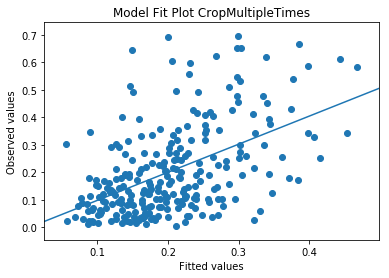

```
GLM Regression for ApplyFertilizer
                 Generalized Linear Model Regression Results
==============================================================================
Dep. Variable:        ApplyFertilizer   No. Observations:                  257
Model:                            GLM   Df Residuals:                      240
Model Family:                Binomial   Df Model:                           16
Link Function:                  logit   Scale:                             1.0
Method:                          IRLS   Log-Likelihood:                -104.17
Date:                Thu, 20 Jul 2017   Deviance:                       83.661
Time:                        22:39:40   Pearson chi2:                     33.7
No. Iterations:                     8
=================================================================================================
                                    coef    std err          z      P>|z|      [95.0% Conf. Int.]
-------------------------------------------------------------------------------------------------
ageOfTheHouseholdHead            -0.0106      0.010     -1.095      0.274        -0.030     0.008
householdSize                    -0.0373      0.062     -0.606      0.544        -0.158     0.083
farmSize                          0.0166      0.037      0.446      0.655        -0.056     0.090
shareOfHiredLabour                0.0011      0.006      0.174      0.862        -0.011     0.013
commercializationIndex            0.0062      0.006      1.011      0.312        -0.006     0.018
totalLabourManDays                0.0002      0.001      0.352      0.725        -0.001     0.001
perCapitaIncome                 2.05e-08   1.98e-07      0.103      0.918     -3.68e-07  4.09e-07
percentNonfarmIncome              0.0082      0.007      1.129      0.259        -0.006     0.022
topgraphicWetnessIndex           -0.0494      0.036     -1.364      0.172        -0.120     0.022
distanceToBigMarket               0.0018      0.010      0.183      0.855        -0.018     0.022
farmType_ AgroPastoralist        -0.7406      0.905     -0.818      0.413        -2.514     1.033
farmType_ Diversifier            -0.4578      0.883     -0.519      0.604        -2.188     1.272
farmType_ Subsistence            -0.5561      0.887     -0.627      0.531        -2.295     1.183
cropChoice_ Maize                -0.2573      0.655     -0.393      0.695        -1.542     1.027
cropChoice_ Rice                 -0.1331      0.665     -0.200      0.841        -1.437     1.170
cropChoice_ RiceAndMaize         -0.6968      0.628     -1.110      0.267        -1.928     0.534
cropChoice_ RiceMaizeAndVegit    -0.3679      0.602     -0.612      0.541        -1.547     0.811
cropChoice_ VegitAndRice         -0.2994      0.604     -0.496      0.620        -1.482     0.884
=================================================================================================
```

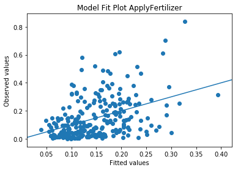

```
GLM Regression for ApplyImprovedSeed
                 Generalized Linear Model Regression Results
==============================================================================
Dep. Variable:      ApplyImprovedSeed   No. Observations:                  257
Model:                            GLM   Df Residuals:                      240
Model Family:                Binomial   Df Model:                           16
Link Function:                  logit   Scale:                             1.0
Method:                          IRLS   Log-Likelihood:                -101.36
Date:                Thu, 20 Jul 2017   Deviance:                       85.971
Time:                        22:39:40   Pearson chi2:                     20.3
No. Iterations:                     8
=================================================================================================
                                    coef    std err          z      P>|z|      [95.0% Conf. Int.]
-------------------------------------------------------------------------------------------------
ageOfTheHouseholdHead             0.0100      0.010      1.008      0.314        -0.009     0.029
householdSize                    -0.0764      0.063     -1.221      0.222        -0.199     0.046
farmSize                          0.0202      0.038      0.530      0.596        -0.055     0.095
shareOfHiredLabour                0.0013      0.006      0.209      0.834        -0.011     0.014
commercializationIndex            0.0028      0.006      0.453      0.650        -0.009     0.015
totalLabourManDays             2.282e-05      0.001      0.035      0.972        -0.001     0.001
perCapitaIncome                3.527e-08   1.96e-07      0.180      0.857     -3.49e-07   4.2e-07
percentNonfarmIncome             -0.0182      0.008     -2.410      0.016        -0.033    -0.003
topgraphicWetnessIndex            0.0264      0.036      0.726      0.468        -0.045     0.098
distanceToBigMarket               0.0121      0.010      1.190      0.234        -0.008     0.032
farmType_ AgroPastoralist        -1.8237      0.936     -1.948      0.051        -3.658     0.011
farmType_ Diversifier            -1.8404      0.908     -2.026      0.043        -3.621    -0.060
farmType_ Subsistence            -1.2776      0.912     -1.401      0.161        -3.065     0.510
cropChoice_ Maize                -0.8314      0.683     -1.217      0.224        -2.171     0.508
cropChoice_ Rice                 -1.2093      0.725     -1.667      0.095        -2.631     0.212
cropChoice_ RiceAndMaize         -1.0053      0.645     -1.559      0.119        -2.269     0.259
cropChoice_ RiceMaizeAndVegit    -0.7453      0.601     -1.240      0.215        -1.923     0.433
cropChoice_ VegitAndRice         -1.1504      0.626     -1.837      0.066        -2.378     0.077
=================================================================================================
```

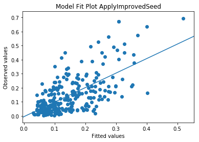

```
GLM Regression for UseIrrigationAndFertilizerApplication
                           Generalized Linear Model Regression Results
=================================================================================================
Dep. Variable:     UseIrrigationAndFertilizerApplication   No. Observations:                  257
Model:                                               GLM   Df Residuals:                      240
Model Family:                                   Binomial   Df Model:                           16
Link Function:                                     logit   Scale:                             1.0
Method:                                             IRLS   Log-Likelihood:                -67.586
Date:                                   Thu, 20 Jul 2017   Deviance:                       44.748
Time:                                           22:39:40   Pearson chi2:                     20.6
No. Iterations:                                        9
=================================================================================================
                                    coef    std err          z      P>|z|      [95.0% Conf. Int.]
-------------------------------------------------------------------------------------------------
ageOfTheHouseholdHead            -0.0020      0.013     -0.162      0.871        -0.027     0.023
householdSize                     0.1100      0.084      1.317      0.188        -0.054     0.274
farmSize                          0.0326      0.050      0.652      0.514        -0.065     0.131
shareOfHiredLabour                0.0024      0.008      0.291      0.771        -0.014     0.019
commercializationIndex            0.0084      0.008      1.019      0.308        -0.008     0.024
totalLabourManDays                0.0006      0.001      0.661      0.508        -0.001     0.002
perCapitaIncome                1.013e-08   2.59e-07      0.039      0.969     -4.98e-07  5.19e-07
percentNonfarmIncome              0.0060      0.010      0.618      0.537        -0.013     0.025
topgraphicWetnessIndex            0.0498      0.048      1.035      0.301        -0.045     0.144
distanceToBigMarket              -0.0271      0.014     -1.947      0.052        -0.054     0.000
farmType_ AgroPastoralist        -3.2849      1.254     -2.620      0.009        -5.742    -0.828
farmType_ Diversifier            -2.9778      1.221     -2.439      0.015        -5.371    -0.584
farmType_ Subsistence            -2.8362      1.232     -2.301      0.021        -5.252    -0.421
cropChoice_ Maize                -1.8132      0.933     -1.943      0.052        -3.642     0.015
cropChoice_ Rice                 -1.6766      0.954     -1.758      0.079        -3.546     0.193
cropChoice_ RiceAndMaize         -2.1091      0.830     -2.541      0.011        -3.736    -0.482
cropChoice_ RiceMaizeAndVegit    -1.8012      0.796     -2.263      0.024        -3.361    -0.241
cropChoice_ VegitAndRice         -1.6989      0.804     -2.113      0.035        -3.275    -0.123
=================================================================================================
```

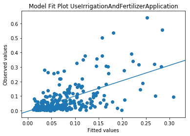

```
GLM Regression for UseIrrigation
                 Generalized Linear Model Regression Results
==============================================================================
Dep. Variable:          UseIrrigation   No. Observations:                  257
Model:                            GLM   Df Residuals:                      240
Model Family:                Binomial   Df Model:                           16
Link Function:                  logit   Scale:                             1.0
Method:                          IRLS   Log-Likelihood:                -28.467
Date:                Thu, 20 Jul 2017   Deviance:                       13.797
Time:                        22:39:40   Pearson chi2:                     6.79
No. Iterations:                    10
=================================================================================================
                                    coef    std err          z      P>|z|      [95.0% Conf. Int.]
-------------------------------------------------------------------------------------------------
ageOfTheHouseholdHead             0.0079      0.022      0.358      0.720        -0.035     0.051
householdSize                    -0.0654      0.143     -0.458      0.647        -0.345     0.214
farmSize                          0.0689      0.087      0.790      0.429        -0.102     0.240
shareOfHiredLabour                0.0036      0.014      0.260      0.795        -0.023     0.031
commercializationIndex           -0.0010      0.014     -0.071      0.943        -0.028     0.026
totalLabourManDays                0.0003      0.001      0.213      0.831        -0.002     0.003
perCapitaIncome                8.011e-08   4.54e-07      0.176      0.860      -8.1e-07  9.71e-07
percentNonfarmIncome              0.0133      0.017      0.795      0.426        -0.020     0.046
topgraphicWetnessIndex            0.0397      0.082      0.484      0.629        -0.121     0.201
distanceToBigMarket              -0.0375      0.026     -1.421      0.155        -0.089     0.014
farmType_ AgroPastoralist        -3.3869      2.201     -1.539      0.124        -7.701     0.927
farmType_ Diversifier            -3.1355      2.176     -1.441      0.150        -7.401     1.130
farmType_ Subsistence            -3.7194      2.268     -1.640      0.101        -8.164     0.725
cropChoice_ Maize                -1.9602      1.607     -1.220      0.222        -5.109     1.189
cropChoice_ Rice                 -2.0234      1.686     -1.200      0.230        -5.327     1.280
cropChoice_ RiceAndMaize         -2.2924      1.433     -1.600      0.110        -5.100     0.516
cropChoice_ RiceMaizeAndVegit    -1.9969      1.475     -1.354      0.176        -4.887     0.894
cropChoice_ VegitAndRice         -1.9689      1.419     -1.388      0.165        -4.750     0.812
=================================================================================================
```

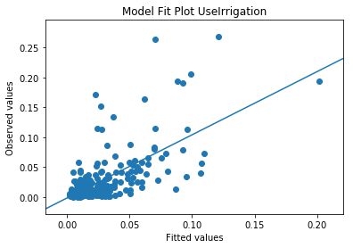

```python
#call for the GLM function
doGLMRegression(DataFrame2, dependentVariables, outComeVariables)
```